# Solutions for exercises of Section 8.

Rob J Hyndman & George Athanasopoulos

## Exercise 8.1

### ACF graphs of white noise

- The difference between figures is that they show different critical values (blue dashed lines).
- All figures indicate that the data is white noise.
- The critical values are at different distances from zero because the data sets have different number of observations. The more observation are in a data set representing white noise the less noise appears in the correlation estimations (spikes). Therefore the critical values for bigger data sets can be smaller in order to check if the data is not white noise.

## Exercise 8.2

### ACF and PACF graphs of dataset ibmclose

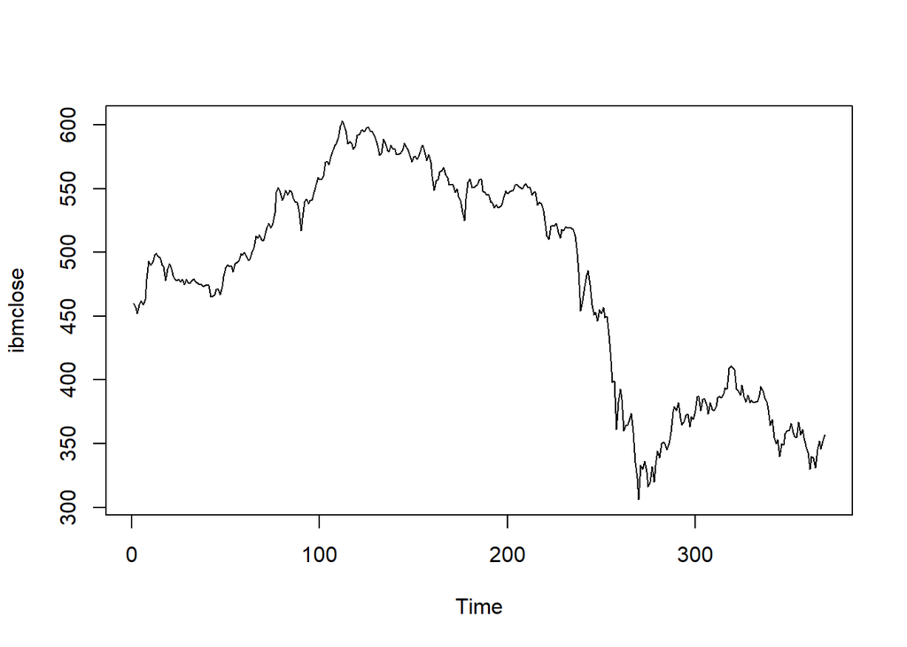

```r
plot(ibmclose)
```

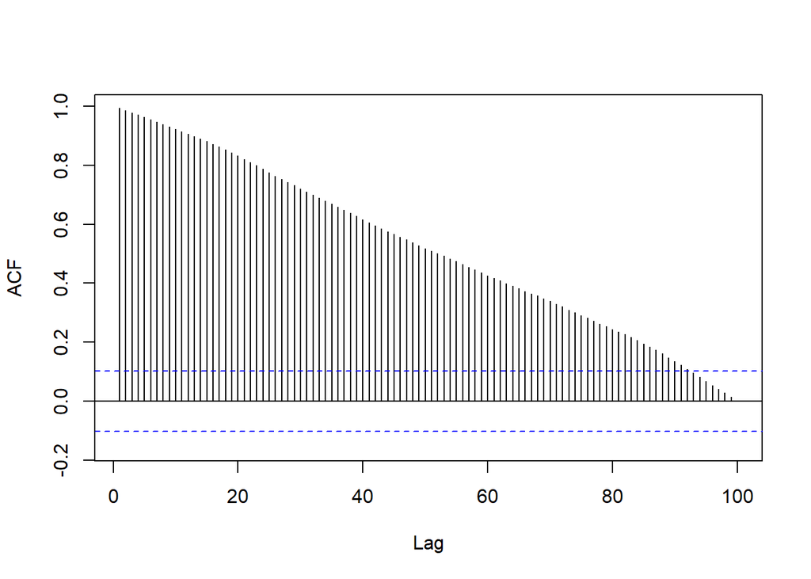

```r
Acf(ibmclose, lag.max = 100, main = "") # lag.max = 100 sets the maximum lag at which to calculate the ACF to 100
```

ACF does not drop quickly to zero, moreover the value $r_1$ is large and positive (almost 1 in this case). All these are signs of a non-stationary time series. Therefore it should be differenced to apply ARMA model.

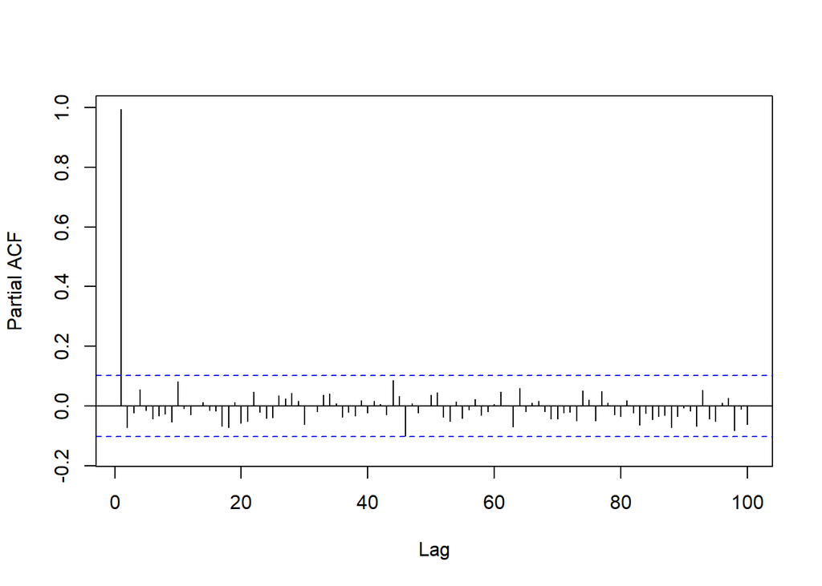

```r
Pacf(ibmclose, lag.max = 100, main = "")
```

PACF value $r_1$ is almost 1. All other values $r_i, i>1$ are smaller than the critical value. These are the signs of random walk process (cumulative sum of independent observations). Since random walk is a non-stationary process the data should be differenced to apply ARMA model.